# 1 matplotlib库简介

## 1.1 什么是matplotlib？

matplotlib是一款命令式、较底层、可定制性强、图表资源丰富、简单易用的python 2D绘图库，以渐进、交互式方式实现数据可视化。

matplotlib支持多种图表的绘制，支持折线图、条形图、直方图、饼图、散点图、面积图、趋势图、箱型图、小提琴图、数据地图、雷达图、漏斗图等等。

使用matplotlib绘图主要是用到其pyplot模块，它可以程序化生成多种多样的图表，只需要简单的函数就可以自主化定制图表，添加文本、点、线、颜色、图像等元素。

## 1.2 为什么使用matplotlib?

matplotlib算是python绘图的元老级库，类似编程语言里的C语言。很多其它的python高级绘图库是基于matplotlib开发的，比如**seaborn**、ggplot、plotnine、holoviews、basemap等。

虽然在实践中，我们可能通过pandas的plot函数或者seaborn库可以直接绘制精美的图表，但如果想要绘制更精美的图表，是很有必要了解底层matplotlib库的一些细节的。

# 2 常用图适用场景

## 2.1 折线图

折线图(line chart)用于显示数据在一个连续的时间间隔或者时间跨度上的变化，它的特点是反映事物随时间或有序类别而变化的趋势。示例图如下：

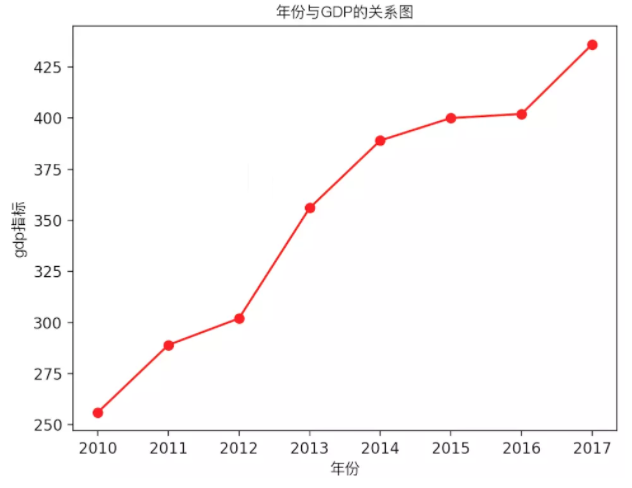

折线图应用场景：

- 折线图适合X轴是一个连续递增或递减的，对于没有规律的，则不适合使用折线图，建议使用条形图。
- 如果折线图条数过多，则不应该都绘制在一个图上。

## 2.2 条形图

典型的条形图（bar chart），使用垂直或水平的柱子显示类别之间的数值比较。其中一个轴表示需要对比的分类，另一个轴代表相应的数值。

条形图有别于直方图，条形图无法显示数据在一个区间内的连续变化趋势。条形图描述的是**分类数据**，回答的是每一个分类中“有多少？”这个问题。 示例图如下：

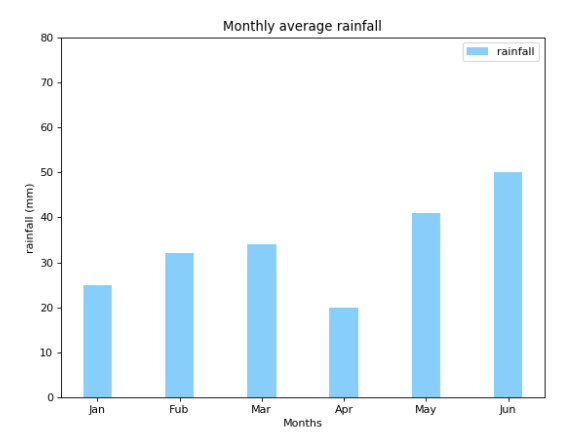

条形图应用场景：

- 适用于分类数据对比。
- 垂直条形图最多不超过12个分类（也就是12个柱形），横向条形图最多不超过30个分类。如果垂直条形图的分类名太长，那么建议换成横向条形图。
- 条形图不适合表示趋势，如果想要表示趋势，应该使用折线图。

## 2.3 直方图

直方图(Histogram)，又称质量分布图，是一种统计报告图，由一系列高度不等的条纹表示数据分布的情况。一般用横轴表示数据类型，纵轴表示分布情况。

直方图是数值数据分布的精确图形表示。为了构建直方图，第一步是将值的范围分段，即将整个值的范围分成一系列间隔，然后计算每个间隔中有多少值。这些值通常被指定为连续的，不重叠的变量间隔。间隔必须相邻，并且通常是（但不是必须的）相等的大小。

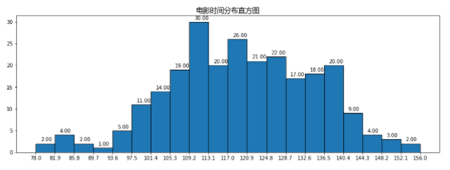

直方图的应用场景：

- 显示各组数据数量分布的情况。
- 用于观察异常或孤立数据。
- 抽取的样本数量过小，将会产生较大误差，可信度低，也就失去了统计的意义。因此，样本数不应少于50个。

## 2.4 散点图

散点图(scatter plot)也叫 X-Y 图，它将所有的数据以点的形式展现在直角坐标系上，以显示变量之间的相互影响程度，点的位置由变量的数值决定。

通过观察散点图上数据点的分布情况，我们可以推断出变量间的相关性。如果变量之间不存在相互关系，那么在散点图上就会表现为随机分布的离散的点，如果存在某种相关性，那么大部分的数据点就会相对密集并以某种趋势呈现。数据的相关关系主要分为：**正相关**（两个变量值同时增长）、**负相关**（一个变量值增加另一个变量值下降）、不相关、线性相关、指数相关等，表现在散点图上的大致分布如下图所示。那些离点集群较远的点我们称为离群点或者异常点。

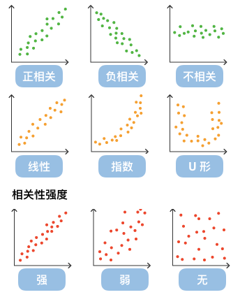

散点图的应用场景：

- 观察数据集的分布情况。
- 通过分析规律，根据样本数据特征计算出回归方程。

## 2.5 饼状图

饼状图通常用来描述量、频率和百分比之间的关系。在饼图中，每个扇区的弧长大小为其所表示的数量的比例。

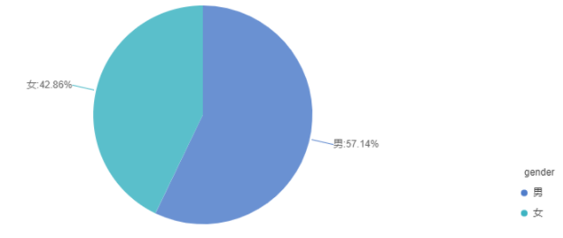

饼状图的应用场景：

- 展示多个分类的占比情况，分类数量建议不超过9个。
- 对于一些占比值非常接近的，不建议使用饼状图，可以使用条形图。